# STAT207 Final Project - Predicting Personal Loan Decision

Brady Brooks Conan Zhang Richard Taing

```python
#Imports!
import numpy as np
import pandas as pd
import seaborn as sns
import matplotlib.pyplot as plt
from sklearn.model_selection import train_test_split
import statsmodels.formula.api as smf
from sklearn.preprocessing import StandardScaler
from sklearn.model_selection import KFold
from sklearn.linear_model import LogisticRegression
from sklearn.linear_model import Lasso
from sklearn.linear_model import Ridge
from sklearn.linear_model import ElasticNet
from sklearn.model_selection import cross_val_score
from sklearn.metrics import roc_auc_score
from sklearn.metrics import roc_curve
from sklearn.metrics import confusion_matrix
import warnings
```

## 1. Introduction

#### Research Motivation

Personal loans can be used in versatile ways such as for debt consolidation, education payments, large purchases, personal investments, and more. By building the best predictive model to predict whether a customer accepts a personal loan, a person can observe how other unique financial backgrounds and situations help influence a decision in taking loans, and make their own financial decision in borrowing money [1]. Additionally, through the model's results, bankers can evaluate what type of customers tend to take personal loans and target that specific audience for their business. Financial advisors can also use the model's results to target consumers who are likely to accept personal loans and allocate more resources and effort into these customers. This can include offering information on the loan application process, loan terms, interest rates, and repayment options. Bankers and financial advisors would thus prefer a classifier that better classifies the positives because they need customers to make money, and by shifting their focus to only those customers who might need loans, they can step in and provide the next steps for the customer.

## 2. Dataset Discussion

#### Dataset Source

This dataset was taken and downloaded from Kaggle on December 2nd, 2023. (https://www.kaggle.com/datasets/krantiswalke/bank-personal-loan-modelling/data). [2]

```python
pd.set_option('display.max_columns', None)
df = pd.read_csv('Bank_Personal_Loan_Modelling.csv')
df.columns = [c.replace(' ', '_') for c in df.columns]
df['Education'] = df['Education'].replace({1:'Undergrad', 2:'Graduate', 3:'Professional'})
df['Personal_Loan'] = df['Personal_Loan'].replace({1:'T', 0:'F'})
df['Securities_Account'] = df['Securities_Account'].replace({1:'T', 0:'F'})
df['CD_Account'] = df['CD_Account'].replace({1:'T', 0:'F'})
df['Online'] = df['Online'].replace({1:'T', 0:'F'})
df['CreditCard'] = df['CreditCard'].replace({1:'T', 0:'F'})
df = df.drop(["ID"], axis=1)
df.head()
```

|  | Age | Experience | Income | ZIP_Code | Family | CCAvg | Education | Mortgage | Personal_Loan | Securities_Account | CD_Account | Online | CreditCard |
| --- | --- | --- | --- | --- | --- | --- | --- | --- | --- | --- | --- | --- | --- |
| 0 | 25 | 1 | 49 | 91107 | 4 | 1.6 | Undergrad | 0 | F | T | F | F | F |
| 1 | 45 | 19 | 34 | 90089 | 3 | 1.5 | Undergrad | 0 | F | T | F | F | F |
| 2 | 39 | 15 | 11 | 94720 | 1 | 1.0 | Undergrad | 0 | F | F | F | F | F |
| 3 | 35 | 9 | 100 | 94112 | 1 | 2.7 | Graduate | 0 | F | F | F | F | F |
| 4 | 35 | 8 | 45 | 91330 | 4 | 1.0 | Graduate | 0 | F | F | F | F | T |

```python
df.shape
```

```
(5000, 13)
```

#### Original Dataset Information

Each observation in the dataset represents a customer from the Thera Bank with a unique set of information (demographics, banking information, financial information, etc.). The entire dataset was generated as a case study from the Thera Bank from one of their previous campaigns to predict if customers took loans or not [2]. This dataset is mostly inclusive of all possible types of observations as it samples a pretty unique demographic set of people each with their own unique financial backgrounds and relationships with the bank. However, the dataset only takes customers from one of their previous campaigns, so any shifts in the market since then, stock changes in the bank, and any customers who don’t use Thera Banking are not included when building our model. The dataset also does not specify which year the campaign was from, possibly making this dataset outdated and biased.

Given these limitations, a banker trying to use this information should generalize the model's results more as a representation of potential financial trends rather than directly applying these results to their own banking institution. Bankers and financial advisors should thus be cautious directly interpreting the model and should explore other banking institution data to see if the trends/results for the Thera Bank holds for other banks.

#### Selected Variables

In conducting our research to find the best predictive model, personal loan will be our response variable (T indicating True, a customer did take a loan and F indicating False, a customer did not take a loan). We thus intend to use all our selected variables to build our model as we would also like to explore which variables have the most predictive power in predicting loan acceptance and which variables essentially don't matter.

## 3. Dataset Cleaning

#### Missing Value Detection and Cleaning

There are no explicit or implicit values within the dataset as all data types look correct. Thus we do not need to remove any rows in this instance.

```python
df.dtypes
```

```
Age                     int64
Experience              int64
Income                  int64
ZIP_Code                int64
Family                  int64
CCAvg                 float64
Education              object
Mortgage                int64
Personal_Loan          object
Securities_Account     object
CD_Account             object
Online                 object
CreditCard             object
dtype: object
```

```python
df.isna().sum()
```

```
Age                   0
Experience            0
Income                0
ZIP_Code              0
Family                0
CCAvg                 0
Education             0
Mortgage              0
Personal_Loan         0
Securities_Account    0
CD_Account            0
Online                0
CreditCard            0
dtype: int64
```

#### Sample Size Cleaning

All categorical variables have a sufficient sample size for each unique observation so there is no need to drop any levels. Also every numerical explanatory variable in the dataframe satisfies a sufficient sample size requirement.

```python
education = df['Education'].value_counts()
education
```

```
Undergrad       2096
Professional    1501
Graduate        1403
Name: Education, dtype: int64
```

```python
pl = df['Personal_Loan'].value_counts()
pl
```

```
F    4520
T     480
Name: Personal_Loan, dtype: int64
```

```python
sa = df['Securities_Account'].value_counts()
sa
```

```
F    4478
T     522
Name: Securities_Account, dtype: int64
```

```python
CDA = df['CD_Account'].value_counts()
CDA
```

```
F    4698
T     302
Name: CD_Account, dtype: int64
```

```python
online = df['Online'].value_counts()
online
```

```
T    2984
F    2016
Name: Online, dtype: int64
```

```python
credit = df['CreditCard'].value_counts()
credit
```

```
F    3530
T    1470
Name: CreditCard, dtype: int64
```

```python
num_df = df[["Age", "Experience", "Income", "Family", "CCAvg", "Mortgage"]]
num_df.head(1)
```

|  | Age | Experience | Income | Family | CCAvg | Mortgage |
| --- | --- | --- | --- | --- | --- | --- |
| 0 | 25 | 1 | 49 | 4 | 1.6 | 0 |

#### Outlier Cleaning - Two Variable Outlier Inspection

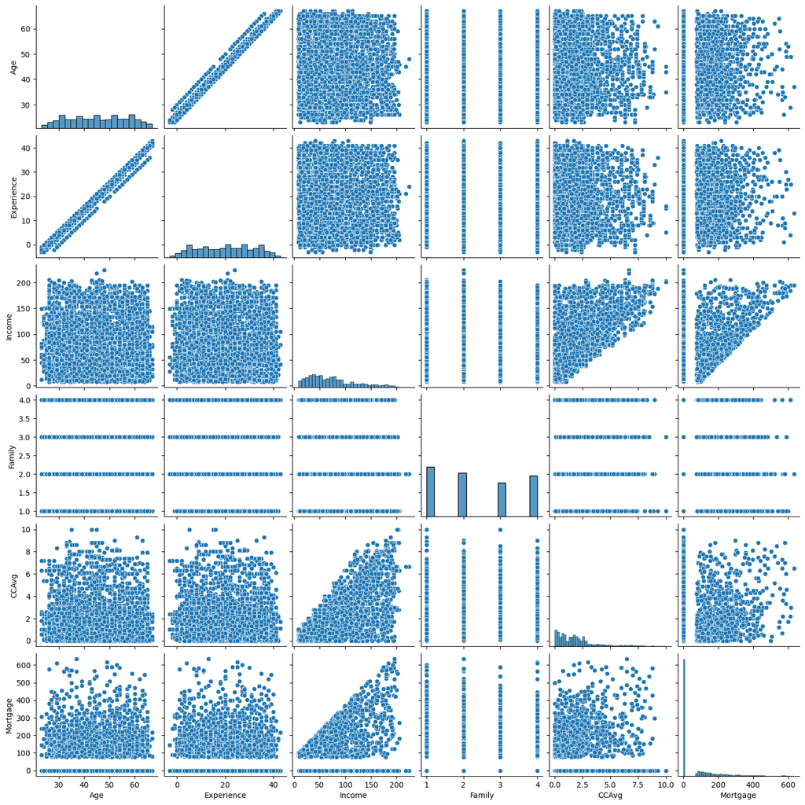

```python
sns.pairplot(num_df)
plt.show()
```

#### Additional Cleaning

Because Zip Code represents a string similar to an ID #, it should not be included in building our model. In our sample size understanding, Zip Code also has multiple levels containing only one observation. Thus the variable is removed from our dataset.

```python
zip = df['ZIP_Code'].value_counts()
zip
```

```
94720    169
94305    127
95616    116
90095     71
93106     57
        ...
96145      1
94087      1
91024      1
9307       1
94598      1
Name: ZIP_Code, Length: 467, dtype: int64
```

```python
df = df.drop(["ZIP_Code"], axis=1)
```

## 4. Preliminary Analysis

#### Relationships between the Response Variable and the Explanatory Variables

Visualizing the relationship between all explanatory variables and the response variable, age and experience appear to have almost no association with personal loan decision due to the high overlap in boxplots. In addition, the categorical variables: Online, Credit Card, and Securities Account also have low association with the response variable due to the relative frequency bars in the barplots being the same distribution. Thus, the explanatory variables with the STRONGEST relationship with the response variable are CD_Account, CC_Avg, Family, Income, while the explanatory variables with the weakest relationship with the response variable are CreditCard, Online, and Age.

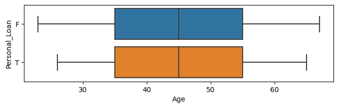

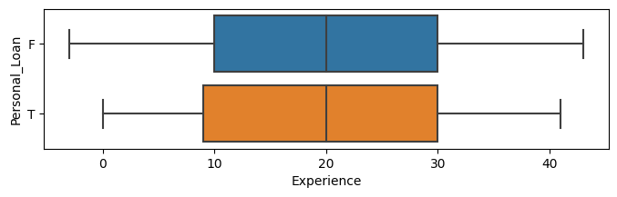

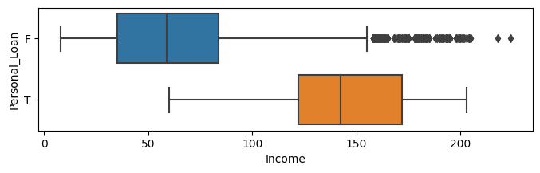

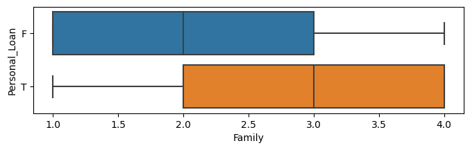

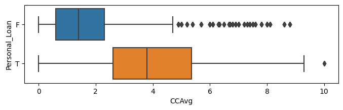

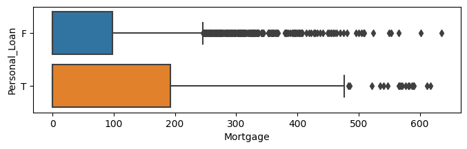

```python
for col in num_df:
    plt.figure(figsize=(8,2))
    sns.boxplot(x=col, y='Personal_Loan', data=df)
    plt.show()
```

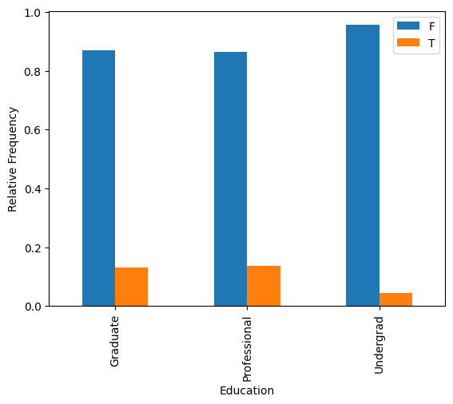

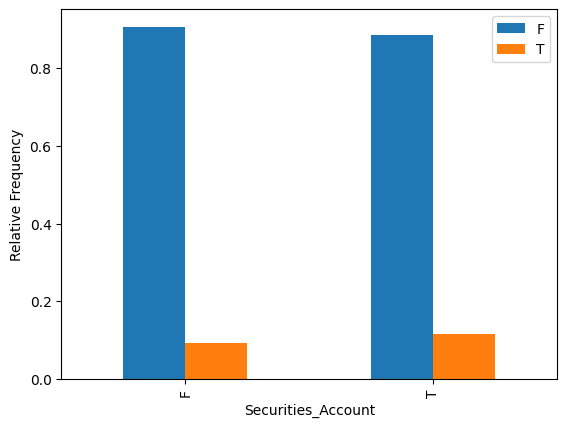

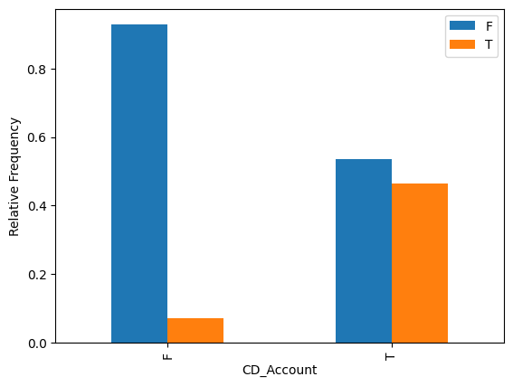

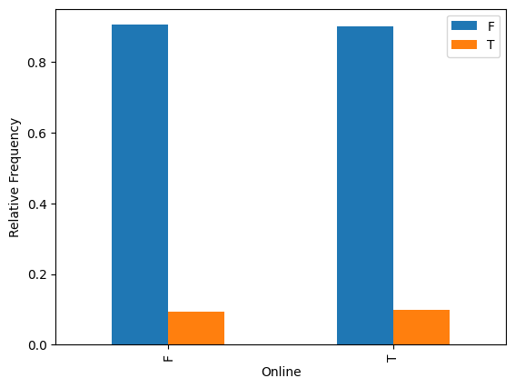

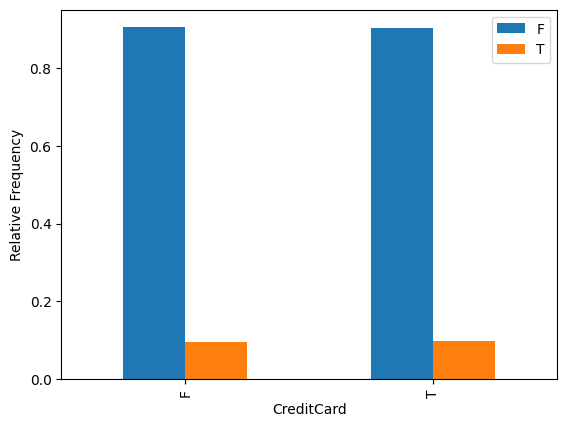

```python
cat_df = df[["Education", "Securities_Account", "CD_Account", "Online", "CreditCard"]]
for cat in cat_df:
    temp = pd.crosstab(df[cat], df['Personal_Loan'], normalize='index')
    temp.plot.bar()
    plt.legend(loc='upper right')
    plt.ylabel('Relative Frequency')
    plt.show()
```

#### Relationships between Explanatory Variable Pairs

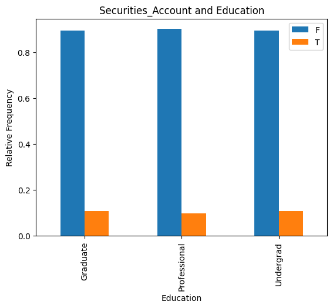

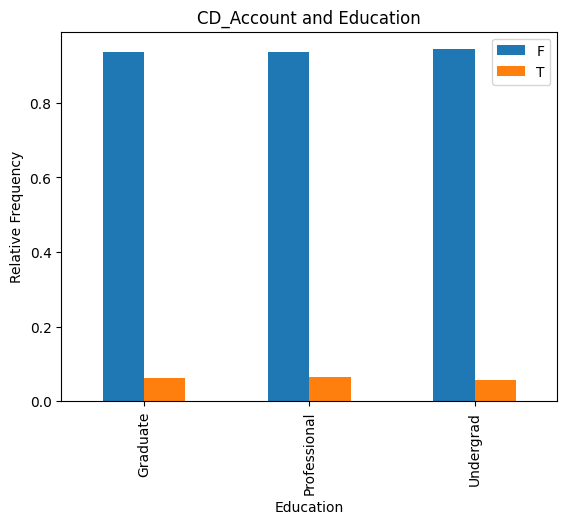

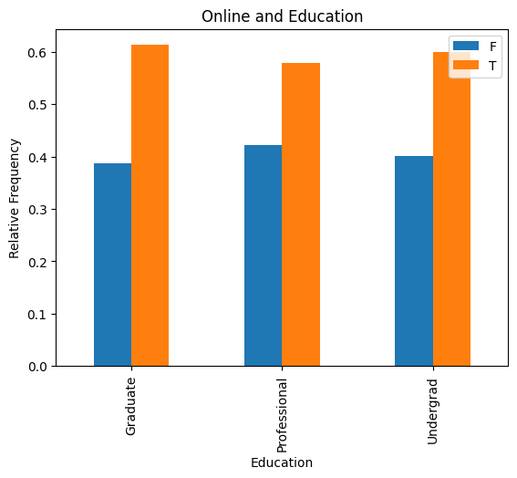

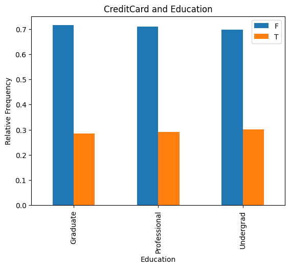

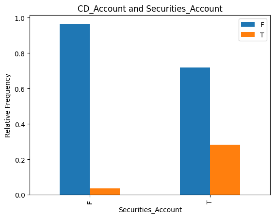

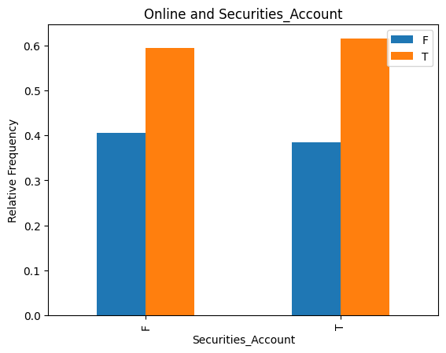

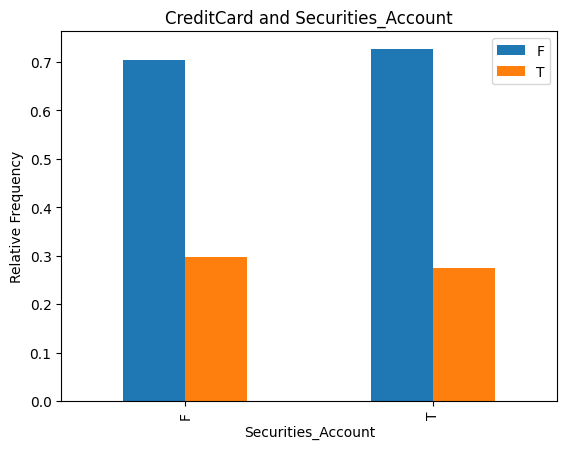

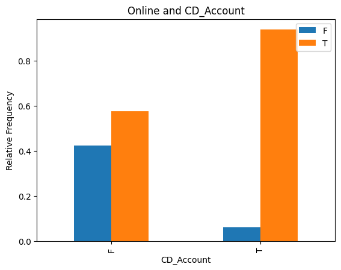

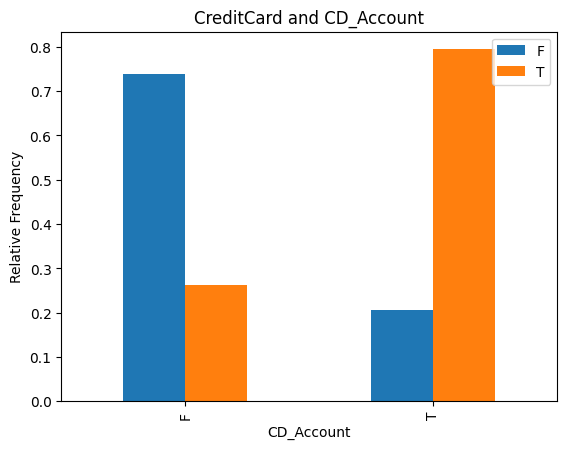

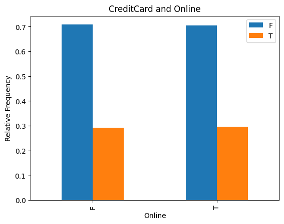

```python
count = 0
for cat in cat_df:
    index = 0
    for cat2 in cat_df:
        if ((cat != cat2) & (index > count)):
            temp = pd.crosstab(df[cat], df[cat2], normalize='index')
            temp.plot.bar()
            plt.legend(loc='upper right')
            plt.ylabel('Relative Frequency')
            plt.title(cat2 + " and " + cat)
            plt.show()
        index = index + 1
    count = count + 1
```